# multichangepoints workflow

This vignette demonstrates the core workflow for sequential change-point detection with:

- IID Gaussian data generating process (DGP)
- simple-vs-simple test supermartingale (TSM)
- Shiryaev-Roberts (S-R) detector

```r
devtools::load_all("~/Dropbox/CANSSI/multi-change-points/")
```

```
#> ℹ Loading multichangepoints
```

```r
library(multichangepoints)
set.seed(20260305)
```

## 1. Specify a Gaussian model and TSM

```r
# define a simple change model, including all pre-change and post-change parameters
model <- GaussianModel(
  mean_pre = 0,
  sd_pre = 1,
  mean_post = 1,
  sd_post = 1
)

# construct a tsm object from the model, it will receive data
tsm <- TSM(model)
```

## 2. Create an IID Gaussian DGP

```r
# set up the data generating process for the data sequence, including the pre/post distributions and the change-point
dgp <- DGP(
  GaussianModel(mean_pre = 0, sd_pre = 1, mean_post = 1, sd_post = 1),
  nu = 120, # change-point
  name = "iid-gaussian-change"
)

# generate data from the dgp
N <- 250
x <- generate_stream(dgp, N = N)
head(x)
```

```
#> [1] -0.2698252 -0.9911324 -0.4595598 -0.8808831 -1.4012064  1.9237771
```

## 3. Build increments and run the S-R detector with ARL control

```r
# increment sequence from data x
inc <- compute_increments(tsm, x, log = TRUE)

# instantiate a detector class with ARL control
sr_1 <- ShiryaevRobertsDetector(
  alpha = 0.05, # average run length without false alarm is only 20
  criterion = "ARL"
)
sr_2 <- ShiryaevRobertsDetector(
  alpha = 0.001, # average run length without false alarm is 1000
  criterion = "ARL"
)


# push increments through detector sr
det_out_1 <- run_detector(sr_1, inc, log = TRUE)
det_out_2 <- run_detector(sr_2, inc, log = TRUE)
str(det_out_1)
```

```
#> List of 6
#>  $ statistic    : num [1:250] -0.77 -1.111 -0.675 -0.969 -1.58 ...
#>  $ stopping_time: int 14
#>  $ alarm_times  : int 14
#>  $ alarm        : logi TRUE
#>  $ criterion    : chr "ARL"
#>  $ log          : logi TRUE
```

The detector returns:

- `statistic`: the S-R path over time
- `stopping_time`: first alarm time (or `Inf`)
- `alarm`: whether an alarm occurred by the horizon

The following figure plots the path of the TSM and ALR-controlled S-R statistic, along with the alarm time.

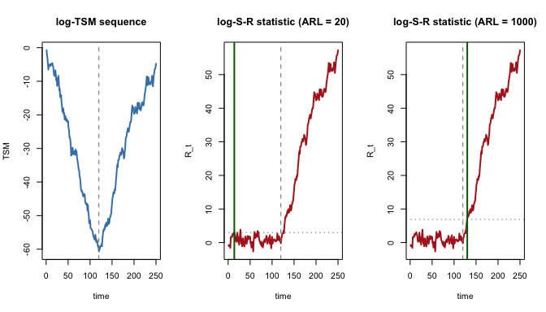

TSM helper path and ARL-controlled S-R statistic with alarm time.

```r
par(mfrow = c(1, 3))

# helper: construct TSM path from increments for visualization
z <- increments_to_tsm(inc, log = TRUE)
plot(z, type = "l", lwd = 2, col = "steelblue",
     main = "log-TSM sequence", xlab = "time", ylab = "TSM")
abline(v = dgp@nu, lty = 2, col = "gray50")

plot(det_out_1$statistic, type = "l", lwd = 2, col = "firebrick",
     main = "log-S-R statistic (ARL = 20)", xlab = "time", ylab = "R_t")
abline(h = log(sr_1@threshold), lty = 3, col = "gray50")
abline(v = dgp@nu, lty = 2, col = "gray50")
if (is.finite(det_out_1$stopping_time)) {
  abline(v = det_out_1$stopping_time, lwd = 2, col = "darkgreen")
}

plot(det_out_2$statistic, type = "l", lwd = 2, col = "firebrick",
     main = "log-S-R statistic (ARL = 1000)", xlab = "time", ylab = "R_t")
abline(h = log(sr_2@threshold), lty = 3, col = "gray50")
abline(v = dgp@nu, lty = 2, col = "gray50")
if (is.finite(det_out_2$stopping_time)) {
  abline(v = det_out_2$stopping_time, lwd = 2, col = "darkgreen")
}
```

```r
par(mfrow = c(1,1))
```

## 4. Build increments and run the S-R detector with PFA control

```r
# define a spending schedule
spend_1 <- dgeom(1:N, p = 0.1) # geometric spending schedule with p = 0.1
spend_2 <- dpois(1:N, lambda = 120) # poisson spending schedule centered at true nu
spend_1 <- spend_1/sum(spend_1) # normalize
spend_2 <- spend_2/sum(spend_2)  # normalize


# instantiate a detectors with PFA control
sr_pfa_1 <- ShiryaevRobertsDetector(
  alpha = 0.05,
  criterion = "PFA",
  spending = spend_1
)
sr_pfa_2 <- ShiryaevRobertsDetector(
  alpha = 0.05,
  criterion = "PFA",
  spending = spend_2
)


# push increments through detector sr
det_out_1 <- run_detector(sr_pfa_1, inc, log = TRUE)
det_out_2 <- run_detector(sr_pfa_2, inc, log = TRUE)
```

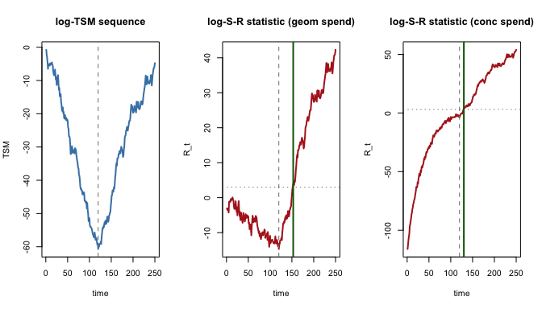

TSM helper path and PFA-controlled S-R statistics with alarm time.

```r
old_par <- par(mfrow = c(1, 3))

plot(z, type = "l", lwd = 2, col = "steelblue",
     main = "log-TSM sequence", xlab = "time", ylab = "TSM")
abline(v = dgp@nu, lty = 2, col = "gray50")

plot(det_out_1$statistic, type = "l", lwd = 2, col = "firebrick",
     main = "log-S-R statistic (geom spend)", xlab = "time", ylab = "R_t")
abline(h = log(sr_pfa_1@threshold), lty = 3, col = "gray50")
abline(v = dgp@nu, lty = 2, col = "gray50")
if (is.finite(det_out_1$stopping_time)) {
  abline(v = det_out_1$stopping_time, lwd = 2, col = "darkgreen")
}


plot(det_out_2$statistic, type = "l", lwd = 2, col = "firebrick",
     main = "log-S-R statistic (conc spend)", xlab = "time", ylab = "R_t")
abline(h = log(sr_pfa_2@threshold), lty = 3, col = "gray50")
abline(v = dgp@nu, lty = 2, col = "gray50")
if (is.finite(det_out_2$stopping_time)) {
  abline(v = det_out_2$stopping_time, lwd = 2, col = "darkgreen")
}
```

```r
par(old_par)
```

## 5. Estimate operating characteristics by simulation

```r
sr <- ShiryaevRobertsDetector(
  alpha = 0.001,
  criterion = "ARL"
)

mc <- run_simulation(
  detector = sr,
  tsm = tsm,
  dgp = dgp,
  n_rep = 100,
  N = 300,
  seed = 77
)

mc
```

```
#>           detector                 dgp n_rep horizon  nu false_alarm_prob
#> 1 shiryaev-roberts iid-gaussian-change   100     300 120              0.1
#>      ARL   ADD   CAD
#> 1 125.12 10.12 10.12
```

This returns Monte Carlo summaries including:

- `false_alarm_prob`: proportion of runs alarming before (or at) the change
- `ARL`: average run length to alarm (censored at horizon)
- `CAD`: average detection delay after the change

## Multivariate detection

Simple-vs-simple multivariate detection. Note that when the alternative is mis-specified, the helper TSM does not grow and the detector can be very inefficient.

```r
K <- 3 # number of streams
N <- 100 # length of streams
dgp_mvn <- DGP(
  MultivariateGaussianModel(
    mu_pre    = c(0, 0, 0), Sigma_pre  = diag(K),
    mu_post   = c(1, 0, 0), Sigma_post = diag(K)
  ),
  nu = 25, # change-point
  name = "mv-gauss-change"
)

# generate data from the dgp
x <- generate_stream(dgp_mvn, N = N)

# true alternative: stream 1 shifts from 0 to 1; streams 2-3 unchanged
model_true <- MultivariateGaussianModel(
  mu_pre = c(0, 0, 0),
  Sigma_pre = diag(K),
  mu_post = c(1, 0, 0),
  Sigma_post = diag(K)
)
# mis-specified alternative: wrongly assumes all streams shift
model_miss <- MultivariateGaussianModel(
  mu_pre = c(0, 0, 0),
  Sigma_pre = diag(K),
  mu_post = c(1, 1, 1),
  Sigma_post = diag(K)
)

# instantiate TSMs and compute increments
inc_true <- compute_increments(TSM(model_true), x, log = TRUE)
inc_miss <- compute_increments(TSM(model_miss), x, log = TRUE)

# instantiate detector and run
sr          <- ShiryaevRobertsDetector(alpha = 0.001, criterion = "ARL")
det_out_true <- run_detector(sr, inc_true, log = TRUE)
det_out_miss <- run_detector(sr, inc_miss, log = TRUE)
```

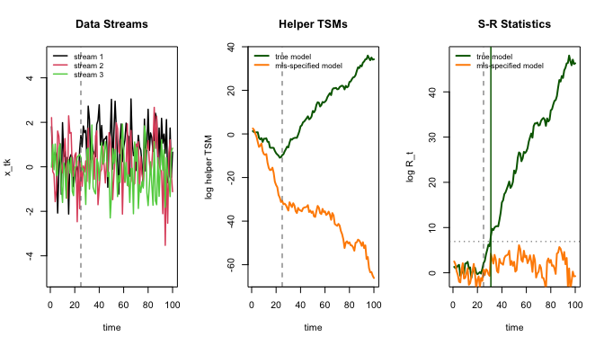

Multivariate data, helper TSMs, and detector statistics (true vs mis-specified alternative).

```r
old_par <- par(mfrow = c(1, 3))

# Panel 1: K data streams
matplot(x, type = "l", lty = 1, lwd = 1.5,
        xlab = "time", ylab = "x_tk", main = "Data Streams", ylim = c(-5, 5))
abline(v = dgp_mvn@nu, lty = 2, col = "gray40")
legend("topleft",
       legend = paste0("stream ", seq_len(ncol(x))),
       col = seq_len(ncol(x)), lty = 1, lwd = 1.5, cex = 0.8, bty = "n")

# Panel 2: log-TSM paths
tsm_true <- compute_tsm(TSM(model_true), x, log = TRUE)
tsm_miss <- compute_tsm(TSM(model_miss), x, log = TRUE)
plot(tsm_true, type = "l", lwd = 2, col = "darkgreen",
     xlab = "time", ylab = "log helper TSM", main = "Helper TSMs",
     ylim = range(c(tsm_true, tsm_miss)))
lines(tsm_miss, lwd = 2, col = "darkorange")
abline(v = dgp_mvn@nu, lty = 2, col = "gray40")
legend("topleft",
       legend = c("true model", "mis-specified model"),
       col = c("darkgreen", "darkorange"),
       lty = 1, lwd = 2, cex = 0.8, bty = "n")

# Panel 3: detector statistics
plot(det_out_true$statistic, type = "l", lwd = 2, col = "darkgreen",
     xlab = "time", ylab = "log R_t", main = "S-R Statistics")
lines(det_out_miss$statistic, lwd = 2, col = "darkorange")
abline(h = log(sr@threshold), lty = 3, col = "gray40")
abline(v = dgp_mvn@nu, lty = 2, col = "gray40")
if (is.finite(det_out_true$stopping_time))
  abline(v = det_out_true$stopping_time, lwd = 1.5, col = "darkgreen")
if (is.finite(det_out_miss$stopping_time))
  abline(v = det_out_miss$stopping_time, lwd = 1.5, col = "darkorange")
legend("topleft",
       legend = c("true model", "mis-specified model"),
       col = c("darkgreen", "darkorange"),
       lty = 1, lwd = 2, cex = 0.8, bty = "n")
```

```r
par(old_par)
```

## Combining

The same `x` from above has K = 3 independent Gaussian streams with a sparse change: only stream 1 shifts from mean 0 to mean 1. We fit a marginal simple-vs-simple TSM for each stream using the true marginal parameters, then combine the resulting increment sequences three ways: product (assumes independence), average (valid under arbitrary dependence), and universal portfolio (valid under arbitrary dependence, adapts weights online).

```r
# ---- marginal models, one per stream ----
# K = 3 streams; Sigma_pre = Sigma_post = I_K, so marginal SD = 1 for all streams
# Stream 1: mean shifts 0 -> 1; streams 2-3: unchanged
mu_pre_marg  <- c(0, 0, 0)
mu_post_marg <- c(1, 0, 0)
sd_marg      <- 1

marg_tsms <- lapply(seq_len(K), function(k) {
  TSM(GaussianModel(
    mean_pre  = mu_pre_marg[k],
    sd_pre    = sd_marg,
    mean_post = mu_post_marg[k],
    sd_post   = sd_marg
  ))
})

# marginal log-increments: N x K matrix (one column per stream)
marg_inc <- sapply(seq_len(K), function(k) {
  compute_increments(marg_tsms[[k]], x[, k], log = TRUE)
})

# ---- combine marginal increments ----
inc_avg <- combine_streams(AverageCombiner(),            marg_inc, log = TRUE)
inc_prd <- combine_streams(ProductCombiner(),            marg_inc, log = TRUE)
inc_up  <- combine_streams(UniversalPortfolioCombiner(), marg_inc, log = TRUE)

# ---- run the same detector on each combined sequence ----
sr_comb <- ShiryaevRobertsDetector(alpha = 0.001, criterion = "ARL")
det_avg <- run_detector(sr_comb, inc_avg, log = TRUE)
det_prd <- run_detector(sr_comb, inc_prd, log = TRUE)
det_up  <- run_detector(sr_comb, inc_up,  log = TRUE)
```

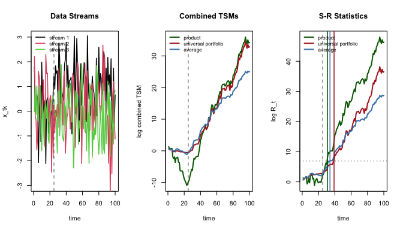

Combining marginal TSMs under sparse change (stream 1 only). Product combining matches the oracle.

```r
old_par <- par(mfrow = c(1, 3))

# Panel 1: data streams (same data as above)
matplot(x, type = "l", lty = 1, lwd = 1.5,
        xlab = "time", ylab = "x_tk", main = "Data Streams", ylim = c(-3, 3))
abline(v = dgp_mvn@nu, lty = 2, col = "gray40")
legend("topleft",
       legend = paste0("stream ", seq_len(K)),
       col = seq_len(K), lty = 1, lwd = 1.5, cex = 0.8, bty = "n")

# Panel 2: combined TSM paths
tsm_avg <- increments_to_tsm(inc_avg, log = TRUE)
tsm_prd <- increments_to_tsm(inc_prd, log = TRUE)
tsm_up  <- increments_to_tsm(inc_up,  log = TRUE)

ylim_tsm <- range(c(tsm_avg, tsm_prd, tsm_up))
plot(tsm_prd, type = "l", lwd = 2, col = "darkgreen",
     xlab = "time", ylab = "log combined TSM", main = "Combined TSMs",
     ylim = ylim_tsm)
lines(tsm_up,  lwd = 2, col = "firebrick")
lines(tsm_avg, lwd = 2, col = "steelblue")
abline(v = dgp_mvn@nu, lty = 2, col = "gray40")
legend("topleft",
       legend = c("product", "universal portfolio", "average"),
       col    = c("darkgreen", "firebrick", "steelblue"),
       lty = 1, lwd = 2, cex = 0.8, bty = "n")

# Panel 3: S-R statistics
ylim_sr <- range(c(det_avg$statistic, det_prd$statistic, det_up$statistic))
plot(det_prd$statistic, type = "l", lwd = 2, col = "darkgreen",
     xlab = "time", ylab = "log R_t", main = "S-R Statistics",
     ylim = ylim_sr)
lines(det_up$statistic,  lwd = 2, col = "firebrick")
lines(det_avg$statistic, lwd = 2, col = "steelblue")
abline(h = log(sr_comb@threshold), lty = 3, col = "gray40")
abline(v = dgp_mvn@nu, lty = 2, col = "gray40")
for (res in list(list(d = det_prd, col = "darkgreen"),
                 list(d = det_up,  col = "firebrick"),
                 list(d = det_avg, col = "steelblue"))) {
  if (is.finite(res$d$stopping_time)) {
    abline(v = res$d$stopping_time, lwd = 1.5, col = res$col)
  }
}
legend("topleft",
       legend = c("product", "universal portfolio", "average"),
       col    = c("darkgreen", "firebrick", "steelblue"),
       lty = 1, lwd = 2, cex = 0.8, bty = "n")
```

```r
par(old_par)
```

## AR(3) change-point detection

So far every example has used iid Gaussian data. Here we demonstrate that the same pipeline handles **autoregressive** observations. We use an AR(3) process with a shift in the long-run mean from 0 (pre-change) to 0.5 (post-change); the AR coefficients and innovation variance are held fixed across regimes so that only the level shifts.

### 1. Define model and simulate data

```r
set.seed(42)
N_ar  <- 300   # total horizon
nu_ar <- 150   # change-point

# AR(3) coefficients: moderate persistence, clearly stationary
phi <- c(0.5, 0.2, 0.1)   # phi_1, phi_2, phi_3  (sum = 0.8 < 1)
sigma_ar <- 0.5

model_ar3 <- GaussianVARModel(
  Phi_pre   = phi,           # numeric vector → list of three 1-by-1 matrices
  Sigma_pre = matrix(sigma_ar^2),
  mean_pre  = 0,
  mean_post = 0.5
)

# Simulate an AR(3) path with a change at nu_ar
intercept_pre  <- model_ar3@mean_pre  * (1 - sum(phi))
intercept_post <- model_ar3@mean_post * (1 - sum(phi))

x_ar <- numeric(N_ar)
x_ar[1:3] <- 0   # initialise at pre-change mean
for (t in 4:N_ar) {
  intercept <- if (t <= nu_ar) intercept_pre else intercept_post
  x_ar[t]   <- intercept +
    phi[1] * x_ar[t - 1] +
    phi[2] * x_ar[t - 2] +
    phi[3] * x_ar[t - 3] +
    rnorm(1, sd = sigma_ar)
}
```

### 2. Compute TSM increments and run the detector

```r
tsm_ar3 <- TSM(model_ar3)

# compute_increments handles the history automatically via the generic loop
inc_ar3 <- compute_increments(tsm_ar3, x_ar, log = TRUE)

sr_ar3  <- ShiryaevRobertsDetector(alpha = 0.001, criterion = "ARL")
det_ar3 <- run_detector(sr_ar3, inc_ar3, log = TRUE)

cat("Stopping time:", det_ar3$stopping_time, "\n")
```

```
#> Stopping time: 283
```

```r
cat("Change-point: ", nu_ar, "\n")
```

```
#> Change-point:  150
```

```r
cat("Detection delay:", det_ar3$stopping_time - nu_ar, "weeks\n")
```

```
#> Detection delay: 133 weeks
```

### 3. Summarise and visualise performance

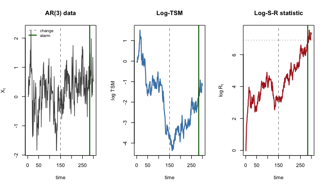

AR(3) change-point detection. Left: simulated path with true change-point (dashed) and alarm (green). Centre: log-TSM path. Right: log-S-R statistic with threshold and alarm.

```r
old_par <- par(mfrow = c(1, 3))

# Panel 1: data
plot(x_ar, type = "l", lwd = 1.2, col = "gray30",
     xlab = "time", ylab = expression(X[t]), main = "AR(3) data")
abline(v = nu_ar, lty = 2, col = "gray50")
if (is.finite(det_ar3$stopping_time))
  abline(v = det_ar3$stopping_time, lwd = 2, col = "darkgreen")
legend("topleft", legend = c("change", "alarm"),
       lty = c(2, 1), lwd = c(1, 2), col = c("gray50", "darkgreen"),
       bty = "n", cex = 0.8)

# Panel 2: log-TSM path
tsm_path_ar3 <- increments_to_tsm(inc_ar3, log = TRUE)
plot(tsm_path_ar3, type = "l", lwd = 2, col = "steelblue",
     xlab = "time", ylab = "log TSM", main = "Log-TSM")
abline(v = nu_ar, lty = 2, col = "gray50")
if (is.finite(det_ar3$stopping_time))
  abline(v = det_ar3$stopping_time, lwd = 2, col = "darkgreen")

# Panel 3: log-S-R statistic
plot(det_ar3$statistic, type = "l", lwd = 2, col = "firebrick",
     xlab = "time", ylab = expression(log~R[t]), main = "Log-S-R statistic")
abline(h = log(sr_ar3@threshold), lty = 3, col = "gray50")
abline(v = nu_ar, lty = 2, col = "gray50")
if (is.finite(det_ar3$stopping_time))
  abline(v = det_ar3$stopping_time, lwd = 2, col = "darkgreen")
```

```r
par(old_par)
```

## Change-point localization

Combining K marginal evidence streams into a single S-R statistic identifies *when* a change occurred, but discards information about *which* streams changed. The `LocalizedDetector` applies the Bonferroni correction to K independent marginal S-R detectors: each stream runs at level α/K, so the union bound guarantees a global ARL ≥ 1/α and global PFA ≤ α while returning per-stream stopping times and statistics.

The tradeoff depends on the sparsity of the change. Under a **uniform** change (all K streams shift), the product-combined increment accumulates K independent post-change likelihood ratios per step, so the joint detector fires dramatically earlier. Under a **sparse** change (only one stream shifts), the picture reverses: the K−1 null-stream log-increments average −0.5 each, pulling the combined log-increment negative on average and making the product-combining detector unreliable or slow — while the localized detector simply watches stream 1’s marginal S-R and is unaffected by the null streams.

We compare both on K = 10 IID Gaussian streams (N(0,1) pre-change, N(1,1) post-change) with a change at ν = 100:

- **Sparse change**: only stream 1 shifts; streams 2–10 are unchanged.
- **Uniform change**: all 10 streams shift simultaneously.

### Setup

```r
K     <- 10
N     <- 500
nu    <- 100
alpha <- 0.001    # global nominal level — ARL >= 1 000

set.seed(20260501)

# Shared marginal model and TSM: N(0,1) -> N(1,1)
marg_model <- GaussianModel(mean_pre = 0, sd_pre = 1, mean_post = 1, sd_post = 1)
marg_tsm   <- TSM(marg_model)

# Sparse scenario: only stream 1 shifts at nu
x_sparse                  <- matrix(rnorm(N * K), nrow = N, ncol = K)
x_sparse[(nu + 1L):N, 1L] <- rnorm(N - nu, mean = 1)

# Uniform scenario: all K streams shift at nu
x_uniform                <- matrix(rnorm(N * K), nrow = N, ncol = K)
x_uniform[(nu + 1L):N, ] <- matrix(rnorm((N - nu) * K, mean = 1), nrow = N - nu, ncol = K)

# Marginal log-increments: N-by-K matrix (column k = stream k)
inc_sparse  <- sapply(seq_len(K), function(k)
  compute_increments(marg_tsm, x_sparse[,  k], log = TRUE))
inc_uniform <- sapply(seq_len(K), function(k)
  compute_increments(marg_tsm, x_uniform[, k], log = TRUE))
```

### Running the detectors

```r
# Joint S-R: one detector at global level alpha fed product-combined log-increments.
# Joint threshold = 1/alpha = 1 000.
sr_joint <- ShiryaevRobertsDetector(alpha = alpha, criterion = "ARL")

det_joint_sparse  <- run_detector(sr_joint,
                       combine_streams(ProductCombiner(), inc_sparse,  log = TRUE),
                       log = TRUE)
det_joint_uniform <- run_detector(sr_joint,
                       combine_streams(ProductCombiner(), inc_uniform, log = TRUE),
                       log = TRUE)

# Localized detector: K marginal S-R detectors, each at level alpha / K = 0.0001.
# Marginal threshold = K / alpha = 10 000.
ld <- LocalizedDetector(K = K, alpha = alpha, criterion = "ARL")

det_loc_sparse  <- run_detector(ld, inc_sparse,  log = TRUE)
det_loc_uniform <- run_detector(ld, inc_uniform, log = TRUE)

# Per-stream N-by-K statistic matrices and K-length stopping-time vectors
stat_loc_sparse  <- sapply(det_loc_sparse$stream_results,  function(r) r$statistic)
stat_loc_uniform <- sapply(det_loc_uniform$stream_results, function(r) r$statistic)
stop_loc_sparse  <- sapply(det_loc_sparse$stream_results,  function(r) r$stopping_time)
stop_loc_uniform <- sapply(det_loc_uniform$stream_results, function(r) r$stopping_time)

loc_thresh_log <- log(ld@detectors[[1L]]@threshold)   # log(K / alpha)

fmt_stop <- function(t, nu) {
  if (is.finite(t)) sprintf("t = %d (delay %d)", as.integer(t), as.integer(t - nu))
  else "no alarm within horizon"
}

cat("--- Joint product S-R (threshold = 1/alpha = 1 000) ---\n")
```

```
#> --- Joint product S-R (threshold = 1/alpha = 1 000) ---
```

```r
cat("  Sparse  (1 stream): ", fmt_stop(det_joint_sparse$stopping_time,  nu), "\n")
```

```
#>   Sparse  (1 stream):  no alarm within horizon
```

```r
cat("  Uniform (K streams):", fmt_stop(det_joint_uniform$stopping_time, nu), "\n")
```

```
#>   Uniform (K streams): t = 101 (delay 1)
```

```r
cat("\n--- Localized S-R (threshold = K/alpha = 10 000 per stream) ---\n")
```

```
#>
#> --- Localized S-R (threshold = K/alpha = 10 000 per stream) ---
```

```r
cat("  Sparse:  stream", det_loc_sparse$first_alarm_stream,
    " ", fmt_stop(det_loc_sparse$stopping_time, nu), "\n")
```

```
#>   Sparse:  stream 1   t = 113 (delay 13)
```

```r
cat(sprintf("  Uniform: %d of %d streams alarmed; first alarm ",
            sum(is.finite(stop_loc_uniform)), K),
    fmt_stop(det_loc_uniform$stopping_time, nu), "\n")
```

```
#>   Uniform: 10 of 10 streams alarmed; first alarm  t = 105 (delay 5)
```

### Scenario 1: sparse change (1 of K streams)

Under sparse change the K−1 null streams each contribute a log-increment with expected value −0.5 per step (the KL divergence with sign reversed under the wrong model). With K = 10 and only stream 1 changing, the combined log-increment averages 0.5 − 9×0.5 = −4 per step: the joint product S-R drifts downward and rarely reaches its threshold within the observation window. The localized detector is unaffected — stream 1’s marginal S-R accumulates 0.5 nats per step against a threshold of log(10 000) ≈ 9.2, alarming after roughly 10 post-change steps — while streams 2–10 remain flat, immediately identifying the source of the change.

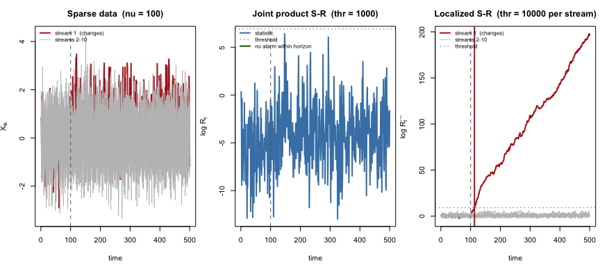

Sparse change: stream 1 shifts from N(0,1) to N(1,1) at nu = 100; streams 2-10 are unchanged. Left: data streams (stream 1 in red). Centre: joint product S-R — the nine null-stream increments pull the combined statistic downward; the threshold is unlikely to be crossed within the horizon. Right: localized per-stream S-R statistics — only stream 1 climbs to the marginal threshold, identifying it as the changed stream.

```r
old_par <- par(mfrow = c(1, 3), mar = c(4.5, 4, 3, 0.5))

s_col <- c("firebrick", rep("gray75", K - 1L))
s_lwd <- c(2,           rep(1,        K - 1L))

# --- Panel 1: data ---
matplot(x_sparse, type = "l", lty = 1, col = s_col, lwd = s_lwd,
        xlab = "time", ylab = expression(X[tk]),
        main = sprintf("Sparse data  (nu = %d)", nu))
abline(v = nu, lty = 2, col = "gray40")
legend("topleft", bty = "n", cex = 0.75,
       legend = c("stream 1  (changes)", "streams 2-10"),
       col = c("firebrick", "gray75"), lty = 1, lwd = c(2, 1))

# --- Panel 2: joint product S-R ---
plot(det_joint_sparse$statistic, type = "l", lwd = 2, col = "steelblue",
     xlab = "time", ylab = expression(log~R[t]),
     main = sprintf("Joint product S-R  (thr = %g)", sr_joint@threshold))
abline(h = log(sr_joint@threshold), lty = 3, col = "gray40")
abline(v = nu, lty = 2, col = "gray40")
if (is.finite(det_joint_sparse$stopping_time)) {
  abline(v = det_joint_sparse$stopping_time, lwd = 2, col = "darkgreen")
  alarm_label <- sprintf("alarm  t = %g", det_joint_sparse$stopping_time)
} else {
  alarm_label <- "no alarm within horizon"
}
legend("topleft", bty = "n", cex = 0.75,
       legend = c("statistic", "threshold", alarm_label),
       col = c("steelblue", "gray40", "darkgreen"),
       lty = c(1, 3, 1), lwd = c(2, 1, 2))

# --- Panel 3: localized per-stream S-R statistics ---
matplot(stat_loc_sparse, type = "l", lty = 1, col = s_col, lwd = s_lwd,
        xlab = "time", ylab = expression(log~R[t]^{(k)}),
        main = sprintf("Localized S-R  (thr = %g per stream)",
                       ld@detectors[[1L]]@threshold))
abline(h = loc_thresh_log, lty = 3, col = "gray40")
abline(v = nu, lty = 2, col = "gray40")
for (k in seq_len(K)) {
  if (is.finite(stop_loc_sparse[k]))
    abline(v = stop_loc_sparse[k], col = s_col[k],
           lwd = if (k == 1L) 2 else 0.8)
}
legend("topleft", bty = "n", cex = 0.75,
       legend = c("stream 1  (changes)", "streams 2-10", "threshold"),
       col = c("firebrick", "gray75", "gray40"),
       lty = c(1, 1, 3), lwd = c(2, 1, 1))
```

```r
par(old_par)
```

### Scenario 2: uniform change (all K streams)

When all K streams shift simultaneously the combined log-increment averages K × 0.5 = 5 nats per step — K times the signal of any single marginal stream — and the joint S-R clears its threshold almost immediately after the change. The localized detector, watching each stream independently at its K-fold higher threshold, takes roughly the same ∼10 steps per stream as in the sparse case, but confirms that all K streams changed.

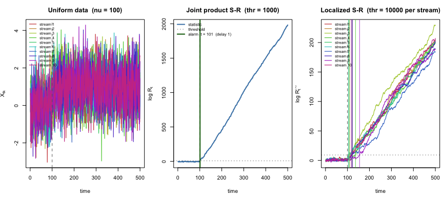

Uniform change: all K = 10 streams shift at nu = 100. Left: data streams. Centre: joint product S-R fires immediately after the change because K independent post-change signals compound multiplicatively. Right: per-stream localized S-R statistics — all K statistics climb in parallel to the marginal threshold, confirming the extent of the change.

```r
old_par <- par(mfrow = c(1, 3), mar = c(4.5, 4, 3, 0.5))

u_col <- rainbow(K, s = 0.7, v = 0.8)

# --- Panel 1: data ---
matplot(x_uniform, type = "l", lty = 1, col = u_col, lwd = 1.2,
        xlab = "time", ylab = expression(X[tk]),
        main = sprintf("Uniform data  (nu = %d)", nu))
abline(v = nu, lty = 2, col = "gray40")
legend("topleft", bty = "n", cex = 0.7,
       legend = paste0("stream ", seq_len(K)), col = u_col, lty = 1, lwd = 1.2)

# --- Panel 2: joint product S-R ---
plot(det_joint_uniform$statistic, type = "l", lwd = 2, col = "steelblue",
     xlab = "time", ylab = expression(log~R[t]),
     main = sprintf("Joint product S-R  (thr = %g)", sr_joint@threshold))
abline(h = log(sr_joint@threshold), lty = 3, col = "gray40")
abline(v = nu, lty = 2, col = "gray40")
if (is.finite(det_joint_uniform$stopping_time))
  abline(v = det_joint_uniform$stopping_time, lwd = 2, col = "darkgreen")
legend("topleft", bty = "n", cex = 0.75,
       legend = c("statistic", "threshold",
                  sprintf("alarm  t = %g  (delay %g)",
                          det_joint_uniform$stopping_time,
                          det_joint_uniform$stopping_time - nu)),
       col = c("steelblue", "gray40", "darkgreen"),
       lty = c(1, 3, 1), lwd = c(2, 1, 2))

# --- Panel 3: per-stream localized S-R statistics ---
matplot(stat_loc_uniform, type = "l", lty = 1, col = u_col, lwd = 1.2,
        xlab = "time", ylab = expression(log~R[t]^{(k)}),
        main = sprintf("Localized S-R  (thr = %g per stream)",
                       ld@detectors[[1L]]@threshold))
abline(h = loc_thresh_log, lty = 3, col = "gray40")
abline(v = nu, lty = 2, col = "gray40")
for (k in seq_len(K)) {
  if (is.finite(stop_loc_uniform[k]))
    abline(v = stop_loc_uniform[k], col = u_col[k], lwd = 0.8)
}
legend("topleft", bty = "n", cex = 0.7,
       legend = paste0("stream ", seq_len(K)), col = u_col, lty = 1, lwd = 1.2)
```

```r
par(old_par)
```

### Comparing delays and localization

Stopping times may be `Inf` if a detector does not alarm within the horizon N = 500; those cases are capped at N − ν for display and marked in grey.

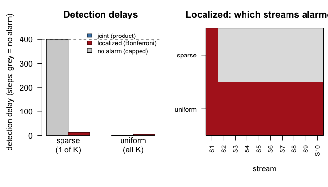

Left: detection delays (capped at the horizon N - nu = 400 for non-alarms, shown in grey). Under sparse change the joint product detector rarely alarms because K-1 null-stream increments overwhelm stream 1’s signal; the localized detector fires quickly on stream 1 alone. Under uniform change the joint product fires almost immediately (K signals compound), while the localized detector takes ~10 steps per stream. Right: binary grid showing which localized streams alarmed — sparse change is pinpointed to stream 1; uniform change lights up all K streams.

```r
old_par <- par(mfrow = c(1, 2), mar = c(5.5, 4.5, 3, 0.5))

cap_delay <- N - nu   # 400: display cap for non-alarms

safe_delay <- function(t) if (is.finite(t)) as.numeric(t - nu) else cap_delay
alarm_col  <- function(t, yes_col) if (is.finite(t)) yes_col else "gray82"

delay_mat <- rbind(
  "joint (product)" = c(safe_delay(det_joint_sparse$stopping_time),
                        safe_delay(det_joint_uniform$stopping_time)),
  "localized"       = c(safe_delay(det_loc_sparse$stopping_time),
                        safe_delay(det_loc_uniform$stopping_time))
)
colnames(delay_mat) <- c("sparse\n(1 of K)", "uniform\n(all K)")

# column-major colour order for barplot(beside = TRUE):
# [col1-row1, col1-row2, col2-row1, col2-row2]
bar_cols <- c(alarm_col(det_joint_sparse$stopping_time,  "steelblue"),
              alarm_col(det_loc_sparse$stopping_time,    "firebrick"),
              alarm_col(det_joint_uniform$stopping_time, "steelblue"),
              alarm_col(det_loc_uniform$stopping_time,   "firebrick"))

# --- Panel 1: delay barplot ---
barplot(delay_mat, beside = TRUE, col = bar_cols,
        ylim = c(0, cap_delay * 1.12),
        ylab = "detection delay (steps; grey = no alarm)",
        main = "Detection delays",
        las = 1)
abline(h = cap_delay, lty = 2, col = "gray50")
legend("topright", bty = "n", cex = 0.8,
       legend = c("joint (product)", "localized (Bonferroni)", "no alarm (capped)"),
       fill   = c("steelblue", "firebrick", "gray82"))

# --- Panel 2: which localized streams alarmed? ---
alarmed_mat <- rbind(
  sparse  = as.integer(is.finite(stop_loc_sparse)),
  uniform = as.integer(is.finite(stop_loc_uniform))
)
# image: x = streams 1:K, y = scenarios 1:2; flip row order so sparse is on top (y=2)
image(seq_len(K), 1:2, t(alarmed_mat[2:1, , drop = FALSE]),
      col  = c("gray88", "firebrick"),
      xaxt = "n", yaxt = "n",
      xlab = "stream", ylab = "",
      main = "Localized: which streams alarmed?")
axis(1, at = seq_len(K), labels = paste0("S", seq_len(K)), las = 2, cex.axis = 0.8)
axis(2, at = 1:2, labels = c("uniform", "sparse"), las = 1, cex.axis = 0.85)
box()
```

```r
par(old_par)
```

The two scenarios reveal a fundamental tradeoff:

- **Sparse change** — the joint product detector is harmed by the K−1 null streams: their increments average −0.5 nats/step each, pulling the combined log-statistic downward so that the threshold is rarely cleared within a finite horizon. The localized detector ignores this dilution — each marginal S-R receives only its own stream’s increments — and correctly fires on stream 1 within ∼10 steps while leaving streams 2–10 quiescent.
- **Uniform change** — the product of K post-change increments grows K times faster in log-space, giving the joint detector an overwhelming speed advantage over the localized detector (which pays the K-fold Bonferroni threshold penalty without benefiting from signal aggregation). The localized detector compensates with diagnostic value: the per-stream alarm map immediately confirms that all K streams have changed.

## BoundedModel: distribution-free detection on approximately bounded streams

We demonstrate on K = 2 independent Gaussian streams with **three distinct structural phases**:

[output not shown]

The null hypothesis is E[X_k] ≤ 0.3 per stream. Phase 2 tests the detector’s **specificity**: because the mean stays at η = 0.3, the TSM should remain flat despite the increased variance. The mean shift in Phase 3 is what we want to detect.

### 1. Simulate data

```r
set.seed(2026)
N_bnd   <- 1000L
nu_bnd  <- 200L   # mean change-point
nu_var  <- 100L   # variance step-change (no mean change)
K_bnd   <- 2L
eta_bnd <- 0.3    # null upper bound on pre-change mean

x_bnd <- matrix(NA_real_, nrow = N_bnd, ncol = K_bnd)

# Phase 1: t = 1..100 — mean 0.3, variance 0.05
x_bnd[seq_len(nu_var), ] <-
  matrix(rnorm(nu_var * K_bnd, mean = 0.3, sd = 0.05), nrow = nu_var)

# Phase 2: t = 101..200 — variance increases to 0.1, mean unchanged
x_bnd[seq(nu_var + 1L, nu_bnd), ] <-
  matrix(rnorm((nu_bnd - nu_var) * K_bnd, mean = 0.3, sd = 0.10),
         nrow = nu_bnd - nu_var)

# Phase 3: t = 201..1000 — stream 1 mean shifts to 0.4; stream 2 unchanged
x_bnd[seq(nu_bnd + 1L, N_bnd), 1] <- rnorm(N_bnd - nu_bnd, mean = 0.4, sd = 0.10)
x_bnd[seq(nu_bnd + 1L, N_bnd), 2] <- rnorm(N_bnd - nu_bnd, mean = 0.3, sd = 0.10)
```

### 2. Build per-stream BoundedModel TSMs

A separate `BoundedModel(eta = 0.3)` is fitted to each stream. `compute_increments` returns the AGRAPA log-increment sequence; `increments_to_tsm` accumulates these into the log-wealth path.

```r
alpha_bnd <- 0.001   # global nominal level — ARL >= 1000

# Per-stream AGRAPA log-increments (N x K matrix)
inc_bnd <- sapply(seq_len(K_bnd), function(k)
  compute_increments(TSM(BoundedModel(eta = eta_bnd)), x_bnd[, k], log = TRUE))

# Cumulative log-wealth paths (N x K matrix)
tsm_bnd <- apply(inc_bnd, 2, function(inc) increments_to_tsm(inc, log = TRUE))
```

### 3. Joint detection (product combining)

The streams are independent by construction, so the product combiner is valid: the combined log-increment sums both streams’ log-increments. Because stream 2 stays on the null, its log-increments average near zero and the combined signal is driven almost entirely by stream 1.

```r
# Combine log-increments multiplicatively (valid since streams are independent)
inc_joint_bnd <- combine_streams(ProductCombiner(), inc_bnd, log = TRUE)

sr_bnd        <- ShiryaevRobertsDetector(alpha = alpha_bnd, criterion = "ARL")
det_joint_bnd <- run_detector(sr_bnd, inc_joint_bnd, log = TRUE)

cat("Joint product S-R  (threshold = 1/alpha =", sr_bnd@threshold, ")\n")
```

```
#> Joint product S-R  (threshold = 1/alpha = 1000 )
```

```r
cat("  Stopping time:", det_joint_bnd$stopping_time, "\n")
```

```
#>   Stopping time: 219
```

```r
if (is.finite(det_joint_bnd$stopping_time))
  cat("  Detection delay:", det_joint_bnd$stopping_time - nu_bnd, "steps\n")
```

```
#>   Detection delay: 19 steps
```

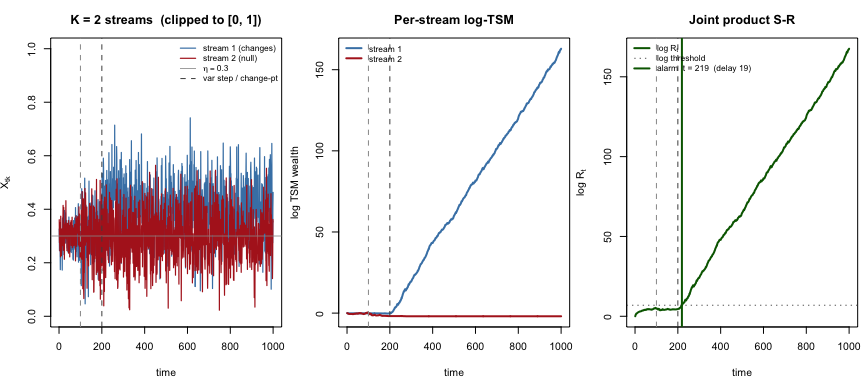

```r
s_cols <- c("steelblue", "firebrick")

old_par <- par(mfrow = c(1, 3), mar = c(4.5, 4, 3, 0.5))

# --- Panel 1: data on [0, 1] ---
matplot(x_bnd, type = "l", lty = 1, lwd = 1.2, col = s_cols,
        xlab = "time", ylab = expression(X[tk]),
        ylim = c(0, 1),
        main = "K = 2 streams  (clipped to [0, 1])")
abline(h = eta_bnd, lty = 1, col = "gray60", lwd = 0.8)
abline(v = nu_var,  lty = 2, col = "gray60")
abline(v = nu_bnd,  lty = 2, col = "gray30")
legend("topright", bty = "n", cex = 0.8,
       legend = c("stream 1 (changes)", "stream 2 (null)",
                  expression(eta == 0.3), "var step / change-pt"),
       col  = c(s_cols, "gray60", "gray30"),
       lty  = c(1, 1, 1, 2), lwd = c(1.2, 1.2, 0.8, 1))

# --- Panel 2: per-stream log-TSM ---
tsm_ylim <- range(tsm_bnd)
matplot(tsm_bnd, type = "l", lty = 1, lwd = 2, col = s_cols,
        xlab = "time", ylab = "log TSM wealth",
        ylim = tsm_ylim,
        main = "Per-stream log-TSM")
abline(v = nu_var, lty = 2, col = "gray60")
abline(v = nu_bnd, lty = 2, col = "gray30")
legend("topleft", bty = "n", cex = 0.8,
       legend = c("stream 1", "stream 2"),
       col = s_cols, lty = 1, lwd = 2)

# --- Panel 3: joint product S-R ---
plot(det_joint_bnd$statistic, type = "l", lwd = 2, col = "darkgreen",
     xlab = "time", ylab = expression(log~R[t]),
     main = "Joint product S-R")
abline(h = log(sr_bnd@threshold), lty = 3, col = "gray40")
abline(v = nu_var, lty = 2, col = "gray60")
abline(v = nu_bnd, lty = 2, col = "gray30")
if (is.finite(det_joint_bnd$stopping_time)) {
  abline(v = det_joint_bnd$stopping_time, lwd = 2, col = "darkgreen")
  tau_label <- sprintf("alarm  t = %d  (delay %d)",
                       as.integer(det_joint_bnd$stopping_time),
                       as.integer(det_joint_bnd$stopping_time - nu_bnd))
} else {
  tau_label <- "no alarm within horizon"
}
legend("topleft", bty = "n", cex = 0.8,
       legend = c(expression(log~R[t]), "log threshold", tau_label),
       col = c("darkgreen", "gray40", "darkgreen"),
       lty = c(1, 3, 1), lwd = c(2, 1, 2))
```

```r
par(old_par)
```

### 4. Localized detection

Because the change is **sparse** (only stream 1 shifts), `LocalizedDetector` is the natural tool. Each of the K marginal S-R detectors runs at level α/K, preserving the global ARL ≥ 1/α by the union bound. The per-stream stopping times immediately identify which stream changed.

```r
ld_bnd      <- LocalizedDetector(K = K_bnd, alpha = alpha_bnd, criterion = "ARL")
det_loc_bnd <- run_detector(ld_bnd, inc_bnd, log = TRUE)

stop_loc_bnd <- sapply(det_loc_bnd$stream_results, function(r) r$stopping_time)
stat_loc_bnd <- sapply(det_loc_bnd$stream_results, function(r) r$statistic)

loc_thresh   <- ld_bnd@detectors[[1L]]@threshold   # K / alpha = 40
cat("Localized S-R  (marginal threshold = K/alpha =", loc_thresh, ")\n")
```

```
#> Localized S-R  (marginal threshold = K/alpha = 2000 )
```

```r
for (k in seq_len(K_bnd)) {
  cat(sprintf("  Stream %d: %s\n", k,
    if (is.finite(stop_loc_bnd[k]))
      sprintf("alarm at t = %d  (delay %d)",
              as.integer(stop_loc_bnd[k]),
              as.integer(stop_loc_bnd[k] - nu_bnd))
    else "no alarm within horizon"))
}
```

```
#>   Stream 1: alarm at t = 219  (delay 19)
#>   Stream 2: no alarm within horizon
```

```r
cat("  Global stopping time:", det_loc_bnd$stopping_time,
    "  (first alarm stream:", det_loc_bnd$first_alarm_stream, ")\n")
```

```
#>   Global stopping time: 219   (first alarm stream: 1 )
```

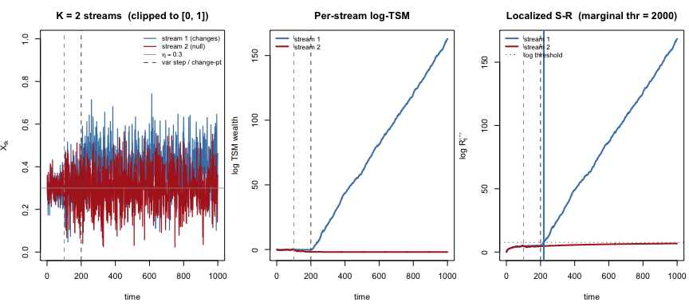

```r
loc_thresh_log_bnd <- log(loc_thresh)

old_par <- par(mfrow = c(1, 3), mar = c(4.5, 4, 3, 0.5))

# --- Panel 1: data ---
matplot(x_bnd, type = "l", lty = 1, lwd = 1.2, col = s_cols,
        xlab = "time", ylab = expression(X[tk]),
        ylim = c(0, 1),
        main = "K = 2 streams  (clipped to [0, 1])")
abline(h = eta_bnd, lty = 1, col = "gray60", lwd = 0.8)
abline(v = nu_var,  lty = 2, col = "gray60")
abline(v = nu_bnd,  lty = 2, col = "gray30")
legend("topright", bty = "n", cex = 0.8,
       legend = c("stream 1 (changes)", "stream 2 (null)",
                  expression(eta == 0.3), "var step / change-pt"),
       col  = c(s_cols, "gray60", "gray30"),
       lty  = c(1, 1, 1, 2), lwd = c(1.2, 1.2, 0.8, 1))

# --- Panel 2: per-stream log-TSM ---
matplot(tsm_bnd, type = "l", lty = 1, lwd = 2, col = s_cols,
        xlab = "time", ylab = "log TSM wealth",
        ylim = tsm_ylim,
        main = "Per-stream log-TSM")
abline(v = nu_var, lty = 2, col = "gray60")
abline(v = nu_bnd, lty = 2, col = "gray30")
legend("topleft", bty = "n", cex = 0.8,
       legend = c("stream 1", "stream 2"),
       col = s_cols, lty = 1, lwd = 2)

# --- Panel 3: per-stream localized S-R ---
matplot(stat_loc_bnd, type = "l", lty = 1, lwd = 2, col = s_cols,
        xlab = "time", ylab = expression(log~R[t]^{(k)}),
        main = sprintf("Localized S-R  (marginal thr = %g)", loc_thresh))
abline(h = loc_thresh_log_bnd, lty = 3, col = "gray40")
abline(v = nu_var, lty = 2, col = "gray60")
abline(v = nu_bnd, lty = 2, col = "gray30")
for (k in seq_len(K_bnd))
  if (is.finite(stop_loc_bnd[k]))
    abline(v = stop_loc_bnd[k], lwd = 2, col = s_cols[k])
legend("topleft", bty = "n", cex = 0.8,
       legend = c("stream 1", "stream 2", "log threshold"),
       col = c(s_cols, "gray40"), lty = c(1, 1, 3), lwd = c(2, 2, 1))
```

```r
par(old_par)
```

The two figures highlight several properties of the AGRAPA-based detector: